# R Notebook

```r
# reading in libraries

library(tidyverse)
library(cluster)
library(factoextra)
library(dendextend)
library(corrplot)
library(janitor)
library(broom)
```

Week 11 Day 3 Homework

Clustering

#1 You have been provided some customer data from a shopping centre. Do some exploratory analysis on the data. Comment on findings.

```r
# reading in data
customer_data <- read_csv("data/mall_customers.csv")

# initial cleaning of data
customer_data <- customer_data %>%
  clean_names()
```

```r
# initial exploration
head(customer_data)
```

| customer_id | gender | age | annual_income_k | spending_score_1_100 |
| --- | --- | --- | --- | --- |
| 1 | Male | 19 | 15 | 39 |
| 2 | Male | 21 | 15 | 81 |
| 3 | Female | 20 | 16 | 6 |
| 4 | Female | 23 | 16 | 77 |
| 5 | Female | 31 | 17 | 40 |
| 6 | Female | 22 | 17 | 76 |

```r
NA
```

There are 5 variables, 200 observations. There is an annual income, and a spending score.

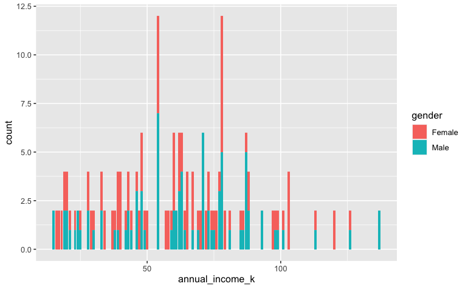

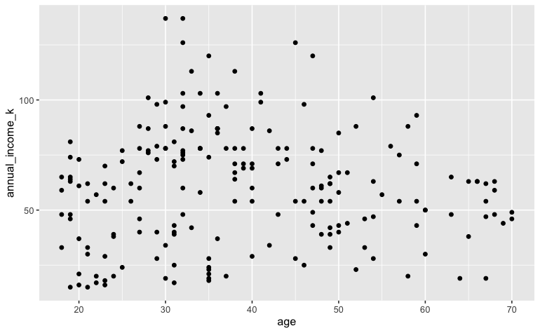

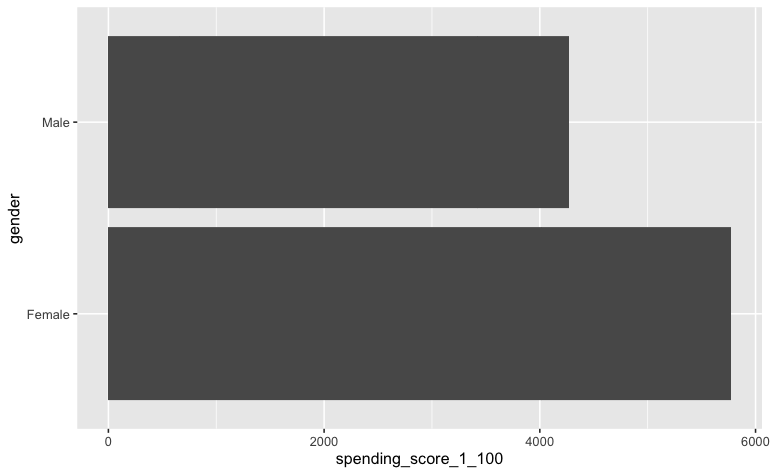

```r
# scaling the data

customer_scale <- customer_data %>%
  select(annual_income_k, spending_score_1_100) %>%
  mutate_if(is.numeric, scale)
```

```r
ggplot(customer_scale, aes(x = annual_income_k, y = spending_score_1_100)) +
  geom_point()
```

[output not shown]

#2 We are interested in creating a marketing campaign to target customers based on their spending score and annual income. Perform a k-means clustering to find if there are meaningful clusters in the data to target the customers.

Based on the above notes, I will set my centers (number of clusters) initially to 5.

```r
clustered_customer <- kmeans(customer_scale,
                             centers = 5,
                             nstart = 25)
clustered_customer
```

```
K-means clustering with 5 clusters of sizes 39, 23, 35, 22, 81

Cluster means:
  annual_income_k spending_score_1_100
1       0.9891010           1.23640011
2      -1.3042458          -1.13411939
3       1.0523622          -1.28122394
4      -1.3262173           1.12934389
5      -0.2004097          -0.02638995

Clustering vector:
  [1] 2 4 2 4 2 4 2 4 2 4 2 4 2 4 2 4 2 4 2 4 2 4 2 4 2 4 2 4 2 4 2 4 2 4 2 4 2 4 2 4 2 4 2 5 2 4 5 5 5 5 5 5 5 5 5 5 5 5 5 5 5 5 5 5 5 5 5 5 5 5 5 5 5 5 5 5 5 5
 [79] 5 5 5 5 5 5 5 5 5 5 5 5 5 5 5 5 5 5 5 5 5 5 5 5 5 5 5 5 5 5 5 5 5 5 5 5 5 5 5 5 5 5 5 5 5 1 3 1 5 1 3 1 3 1 5 1 3 1 3 1 3 1 3 1 5 1 3 1 3 1 3 1 3 1 3 1 3 1
[157] 3 1 3 1 3 1 3 1 3 1 3 1 3 1 3 1 3 1 3 1 3 1 3 1 3 1 3 1 3 1 3 1 3 1 3 1 3 1 3 1 3 1 3 1

Within cluster sum of squares by cluster:
[1] 19.655252  7.577407 18.304646  5.217630 14.485632
 (between_SS / total_SS =  83.6 %)

Available components:

[1] "cluster"      "centers"      "totss"        "withinss"     "tot.withinss" "betweenss"    "size"         "iter"         "ifault"
```

To get this information in a better format, I’ll use the tidy() function

| annual_income_k | spending_score_1_100 | size | withinss | cluster |
| --- | --- | --- | --- | --- |
| 0.9891010 | 1.23640011 | 39 | 19.655252 | 1 |
| -1.3042458 | -1.13411939 | 23 | 7.577407 | 2 |
| 1.0523622 | -1.28122394 | 35 | 18.304646 | 3 |
| -1.3262173 | 1.12934389 | 22 | 5.217630 | 4 |
| -0.2004097 | -0.02638995 | 81 | 14.485632 | 5 |

Gathering my cluster information.

| k | kclust | tidied | glanced | augmented |
| --- | --- | --- | --- | --- |
| 1 |  |  |  |  |
| 2 |  |  |  |  |
| 3 |  |  |  |  |
| 4 |  |  |  |  |
| 5 |  |  |  |  |
| 6 |  |  |  |  |
| 7 |  |  |  |  |
| 8 |  |  |  |  |
| 9 |  |  |  |  |
| 10 |  |  |  |  |

[output cut: 10 more lines]

To begin to evaluate this model, I will first use the elbow method.

| k | kclust | tidied | totss | tot.withinss | betweenss | iter | augmented |
| --- | --- | --- | --- | --- | --- | --- | --- |
| 1 |  |  | 398 | 398.00000 | -1.023182e-12 | 1 |  |
| 2 |  |  | 398 | 267.67171 | 1.303283e+02 | 1 |  |
| 3 |  |  | 398 | 156.91549 | 2.410845e+02 | 3 |  |
| 4 |  |  | 398 | 108.37671 | 2.896233e+02 | 3 |  |
| 5 |  |  | 398 | 65.24057 | 3.327594e+02 | 3 |  |
| 6 |  |  | 398 | 54.78206 | 3.432179e+02 | 3 |  |
| 7 |  |  | 398 | 44.64043 | 3.533596e+02 | 3 |  |
| 8 |  |  | 398 | 36.96238 | 3.610376e+02 | 4 |  |
| 9 |  |  | 398 | 33.63864 | 3.643614e+02 | 3 |  |
| 10 |  |  | 398 | 29.12360 | 3.688764e+02 | 3 |  |

[output cut: 10 more lines]

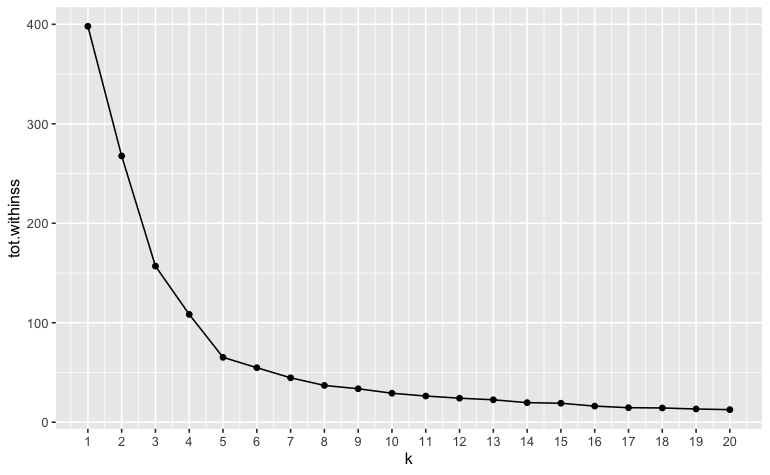

This doesn’t really give me a clear answer. It just trails off - maybe there’s a bend after 5.

Next, I’ll try the silhouette coefficient.

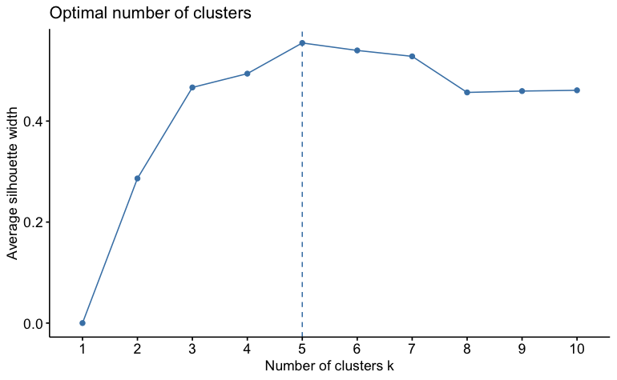

This gives a clearer line of 5, which is in line with what I initially thought from my plot.

Lastly, I’ll try the gap statistic.

```
Clustering k = 1,2,..., K.max (= 10): .. done
Bootstrapping, b = 1,2,..., B (= 100)  [one "." per sample]:
.................................................. 50
.................................................. 100
```

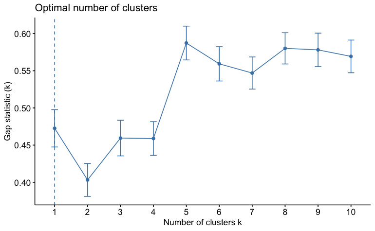

```r
fviz_nbclust(customer_scale,
             kmeans,
             method = "gap_stat",
             nstart = 25,
             k.max = 10)
```

This plot shows that 1 is best.

An important note, is that the 3 methods are giving different results, so the model may not be well suited for k-means clustering.

However, I will proceed with 5, which is what I had from the initial plot, and what two of the above tests suggest.

#3 Perform k-means clustering and chose a value of k.

I will now completed the k-means clustering again, with the chosen number of 5.

```r
clustered_customer_confirmed <- kmeans(customer_scale,
                             centers = 5,
                             nstart = 25)
clustered_customer_confirmed
```

```
K-means clustering with 5 clusters of sizes 39, 81, 22, 23, 35

Cluster means:
  annual_income_k spending_score_1_100
1       0.9891010           1.23640011
2      -0.2004097          -0.02638995
3      -1.3262173           1.12934389
4      -1.3042458          -1.13411939
5       1.0523622          -1.28122394

Clustering vector:
  [1] 4 3 4 3 4 3 4 3 4 3 4 3 4 3 4 3 4 3 4 3 4 3 4 3 4 3 4 3 4 3 4 3 4 3 4 3 4 3 4 3 4 3 4 2 4 3 2 2 2 2 2 2 2 2 2 2 2 2 2 2 2 2 2 2 2 2 2 2 2 2 2 2 2 2 2 2 2 2
 [79] 2 2 2 2 2 2 2 2 2 2 2 2 2 2 2 2 2 2 2 2 2 2 2 2 2 2 2 2 2 2 2 2 2 2 2 2 2 2 2 2 2 2 2 2 2 1 5 1 2 1 5 1 5 1 2 1 5 1 5 1 5 1 5 1 2 1 5 1 5 1 5 1 5 1 5 1 5 1
[157] 5 1 5 1 5 1 5 1 5 1 5 1 5 1 5 1 5 1 5 1 5 1 5 1 5 1 5 1 5 1 5 1 5 1 5 1 5 1 5 1 5 1 5 1

Within cluster sum of squares by cluster:
[1] 19.655252 14.485632  5.217630  7.577407 18.304646
 (between_SS / total_SS =  83.6 %)

Available components:

[1] "cluster"      "centers"      "totss"        "withinss"     "tot.withinss" "betweenss"    "size"         "iter"         "ifault"
```

| annual_income_k | spending_score_1_100 | size | withinss | cluster |
| --- | --- | --- | --- | --- |
| 0.9891010 | 1.23640011 | 39 | 19.655252 | 1 |
| -0.2004097 | -0.02638995 | 81 | 14.485632 | 2 |
| -1.3262173 | 1.12934389 | 22 | 5.217630 | 3 |
| -1.3042458 | -1.13411939 | 23 | 7.577407 | 4 |
| 1.0523622 | -1.28122394 | 35 | 18.304646 | 5 |

Gathering my confirmed cluster information.

```r
max_k <- 20

k_customer_clusters <- tibble(k = 1:max_k) %>%
  mutate(
    kclust = map(k, ~ kmeans(customer_scale, .x, nstart = 25)),
    tidied = map(kclust, tidy),
    glanced = map(kclust, glance),
    augmented = map(kclust, augment, customer_data)
  )

k_customer_clusters
```

| k | kclust | tidied | glanced | augmented |
| --- | --- | --- | --- | --- |
| 1 |  |  |  |  |
| 2 |  |  |  |  |
| 3 |  |  |  |  |
| 4 |  |  |  |  |
| 5 |  |  |  |  |
| 6 |  |  |  |  |
| 7 |  |  |  |  |
| 8 |  |  |  |  |
| 9 |  |  |  |  |
| 10 |  |  |  |  |

[output cut: 10 more lines]

#4 Visualise the clustering for your chosen value of k.

I will now visualise the clustering.

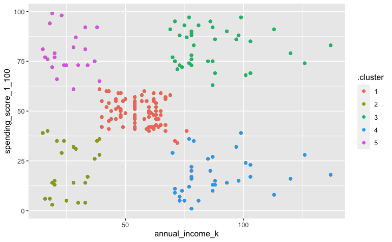

```r
k_customer_clusters %>%
  unnest(cols = c(augmented)) %>%
  filter(k <= 5) %>%
  ggplot(aes(x = annual_income_k, y = spending_score_1_100)) +
  geom_point(aes(color = .cluster))
```

#5 Do you think the clustering seems a good fit for this data?

Yes - it seems to fit the data pretty well. I’ve been able to model 5 distinct groups (see more below), which I was able to formulate a clear hypothesis about in my data exploration, through my testing (elbow test etc) to my final plot, where I would argue I have been able to model these.

#6 Comment on the attributes on one or two of the clusters (maybe even give them a label if you like - like in section 4.1 of the ‘Segmentation & clustering intro’ lesson).

There are 5 clear clusters, A1, A2, B1, C1, C2. A1 have lower incomes, with low spending scores. B1 are median incomes, with median spending scores. They are likely to be middle class, possibly young professional couples, as they sit across the middle of the dataset. C1 are higher incomes, low spending scores. They are likely to be single career-focused professionals, with no children.